# MAZ Sampling

# Remote I/O

```r
interim_dir <- "../"

trips_filename <- paste0(interim_dir, "output/final_trips.csv")
maz_filename <- paste0(interim_dir, "inputs/mgra15_based_input2022.csv")

temp_trips_filename <- paste0(interim_dir, "output/final_trips.RDS")
```

# Data Reads

Minor note: the index column is confusing and should probably be removed. ActivitySim output is bloated.

```r
maz_df <- read_csv(maz_filename, col_types = cols(
  ...1 = col_double(),
  taz = col_double(),
  luz_id = col_double(),
  pop = col_double(),
  hhp = col_double(),
  hs = col_double(),
  hs_sf = col_double(),
  hs_mf = col_double(),
  hs_mh = col_double(),
  hh = col_double(),
  hh_sf = col_double(),
  hh_mf = col_double(),
  hh_mh = col_double(),
  hhs = col_double(),
  gq_civ = col_double(),
  gq_mil = col_double(),
  i1 = col_double(),
  i2 = col_double(),
  i3 = col_double(),
  i4 = col_double(),
  i5 = col_double(),
  i6 = col_double(),
  i7 = col_double(),
  i8 = col_double(),
  i9 = col_double(),
  i10 = col_double(),
  pseudomsa = col_double(),
  zip09 = col_double(),
  enrollgradekto8 = col_double(),
  enrollgrade9to12 = col_double(),
  collegeenroll = col_double(),
  majorcollege_pt_Undergrad = col_double(),
  majorcollege_ft_Undergrad = col_double(),
  majorcollege_All_Undergrad = col_double(),
  major_All_Graduate = col_double(),
  othercollegeenroll = col_double(),
  othercollege_pt_Undergrad = col_double(),
  othercollege_ft_Undergrad = col_double(),
  othercollege_All_Undergrad = col_double(),
  othercollege_All_Graduate = col_double(),
  hotelroomtotal = col_double(),
  parkactive = col_double(),
  openspaceparkpreserve = col_double(),
  beachactive = col_double(),
  district27 = col_double(),
  milestocoast = col_double(),
  acres = col_double(),
  land_acres = col_double(),
  effective_acres = col_double(),
  truckregiontype = col_double(),
  emp_gov = col_double(),
  emp_mil = col_double(),
  emp_ag_min = col_double(),
  emp_bus_svcs = col_double(),
  emp_fin_res_mgm = col_double(),
  emp_educ = col_double(),
  emp_hlth = col_double(),
  emp_ret = col_double(),
  emp_trn_wrh = col_double(),
  emp_con = col_double(),
  emp_utl = col_double(),
  emp_mnf = col_double(),
  emp_whl = col_double(),
  emp_ent = col_double(),
  emp_accm = col_double(),
  emp_food = col_double(),
  emp_oth = col_double(),
  emp_non_ws_wfh = col_double(),
  emp_non_ws_oth = col_double(),
  emp_total = col_double(),
  totint = col_double(),
  duden = col_double(),
  empden = col_double(),
  popden = col_double(),
  retempden = col_double(),
  totintbin = col_double(),
  empdenbin = col_double(),
  dudenbin = col_double(),
  PopEmpDenPerMi = col_double(),
  ech_dist = col_double(),
  hch_dist = col_double(),
  adultschenrl = col_double(),
  hstallsoth = col_double(),
  hstallssam = col_double(),
  numfreehrs = col_double(),
  dstallsoth = col_double(),
  dstallssam = col_double(),
  mstallsoth = col_double(),
  mstallssam = col_double(),
  budgetroom = col_double(),
  economyroom = col_double(),
  luxuryroom = col_double(),
  midpriceroom = col_double(),
  upscaleroom = col_double(),
  MicroAccessTime = col_double(),
  remoteAVParking = col_double(),
  refueling_stations = col_double(),
  mgra = col_double(),
  exp_hourly = col_double(),
  exp_daily = col_double(),
  exp_monthly = col_double(),
  parking_type = col_double(),
  parking_spaces = col_double()
))
trips_df <- read_csv(trips_filename, col_types = cols(
  trip_id = col_double(),
  person_id = col_double(),
  household_id = col_double(),
  primary_purpose = col_character(),
  trip_num = col_double(),
  outbound = col_logical(),
  trip_count = col_double(),
  destination = col_double(),
  origin = col_double(),
  tour_id = col_double(),
  escort_participants = col_character(),
  school_escort_direction = col_character(),
  purpose = col_character(),
  destination_logsum = col_double(),
  depart = col_double(),
  trip_mode = col_character(),
  mode_choice_logsum = col_double(),
  vot_da = col_double(),
  vot_s2 = col_double(),
  vot_s3 = col_double(),
  ownsTransponder = col_logical(),
  parking_zone = col_double(),
  trip_period = col_character(),
  tour_participants = col_double(),
  distance = col_double(),
  is_ea = col_logical(),
  is_am = col_logical(),
  is_md = col_logical(),
  is_pm = col_logical(),
  is_ev = col_logical(),
  ownTrp = col_logical(),
  vot1 = col_double(),
  vot2 = col_double(),
  vot3 = col_double(),
  inbound = col_logical(),
  DRIVEALONE_NOTR_EA_LOW = col_double(),
  SHARED2_NOTR_EA_LOW = col_double(),
  SHARED3_NOTR_EA_LOW = col_double(),
  DRIVEALONE_TR_EA_LOW = col_double(),
  SHARED2_TR_EA_LOW = col_double(),
  SHARED3_TR_EA_LOW = col_double(),
  DRIVEALONE_NOTR_EA_MED = col_double(),
  SHARED2_NOTR_EA_MED = col_double(),
  SHARED3_NOTR_EA_MED = col_double(),
  DRIVEALONE_TR_EA_MED = col_double(),
  SHARED2_TR_EA_MED = col_double(),
  SHARED3_TR_EA_MED = col_double(),
  DRIVEALONE_NOTR_EA_HIGH = col_double(),
  SHARED2_NOTR_EA_HIGH = col_double(),
  SHARED3_NOTR_EA_HIGH = col_double(),
  DRIVEALONE_TR_EA_HIGH = col_double(),
  SHARED2_TR_EA_HIGH = col_double(),
  SHARED3_TR_EA_HIGH = col_double(),
  WALK_LOC_EA = col_double(),
  WALK_PRM_EA = col_double(),
  WALK_MIX_EA = col_double(),
  PNR_LOCOUT_EA = col_double(),
  PNR_PRMOUT_EA = col_double(),
  PNR_MIXOUT_EA = col_double(),
  KNR_LOCOUT_EA = col_double(),
  KNR_PRMOUT_EA = col_double(),
  KNR_MIXOUT_EA = col_double(),
  TNC_LOCOUT_EA = col_double(),
  TNC_PRMOUT_EA = col_double(),
  TNC_MIXOUT_EA = col_double(),
  PNR_LOCIN_EA = col_double(),
  PNR_PRMIN_EA = col_double(),
  PNR_MIXIN_EA = col_double(),
  KNR_LOCIN_EA = col_double(),
  KNR_PRMIN_EA = col_double(),
  KNR_MIXIN_EA = col_double(),
  TNC_LOCIN_EA = col_double(),
  TNC_PRMIN_EA = col_double(),
  TNC_MIXIN_EA = col_double(),
  BIKE_EA = col_double(),
  WALK_EA = col_double(),
  DRIVEALONE_NOTR_AM_LOW = col_double(),
  SHARED2_NOTR_AM_LOW = col_double(),
  SHARED3_NOTR_AM_LOW = col_double(),
  DRIVEALONE_TR_AM_LOW = col_double(),
  SHARED2_TR_AM_LOW = col_double(),
  SHARED3_TR_AM_LOW = col_double(),
  DRIVEALONE_NOTR_AM_MED = col_double(),
  SHARED2_NOTR_AM_MED = col_double(),
  SHARED3_NOTR_AM_MED = col_double(),
  DRIVEALONE_TR_AM_MED = col_double(),
  SHARED2_TR_AM_MED = col_double(),
  SHARED3_TR_AM_MED = col_double(),
  DRIVEALONE_NOTR_AM_HIGH = col_double(),
  SHARED2_NOTR_AM_HIGH = col_double(),
  SHARED3_NOTR_AM_HIGH = col_double(),
  DRIVEALONE_TR_AM_HIGH = col_double(),
  SHARED2_TR_AM_HIGH = col_double(),
  SHARED3_TR_AM_HIGH = col_double(),
  WALK_LOC_AM = col_double(),
  WALK_PRM_AM = col_double(),
  WALK_MIX_AM = col_double(),
  PNR_LOCOUT_AM = col_double(),
  PNR_PRMOUT_AM = col_double(),
  PNR_MIXOUT_AM = col_double(),
  KNR_LOCOUT_AM = col_double(),
  KNR_PRMOUT_AM = col_double(),
  KNR_MIXOUT_AM = col_double(),
  TNC_LOCOUT_AM = col_double(),
  TNC_PRMOUT_AM = col_double(),
  TNC_MIXOUT_AM = col_double(),
  PNR_LOCIN_AM = col_double(),
  PNR_PRMIN_AM = col_double(),
  PNR_MIXIN_AM = col_double(),
  KNR_LOCIN_AM = col_double(),
  KNR_PRMIN_AM = col_double(),
  KNR_MIXIN_AM = col_double(),
  TNC_LOCIN_AM = col_double(),
  TNC_PRMIN_AM = col_double(),
  TNC_MIXIN_AM = col_double(),
  BIKE_AM = col_double(),
  WALK_AM = col_double(),
  DRIVEALONE_NOTR_MD_LOW = col_double(),
  SHARED2_NOTR_MD_LOW = col_double(),
  SHARED3_NOTR_MD_LOW = col_double(),
  DRIVEALONE_TR_MD_LOW = col_double(),
  SHARED2_TR_MD_LOW = col_double(),
  SHARED3_TR_MD_LOW = col_double(),
  DRIVEALONE_NOTR_MD_MED = col_double(),
  SHARED2_NOTR_MD_MED = col_double(),
  SHARED3_NOTR_MD_MED = col_double(),
  DRIVEALONE_TR_MD_MED = col_double(),
  SHARED2_TR_MD_MED = col_double(),
  SHARED3_TR_MD_MED = col_double(),
  DRIVEALONE_NOTR_MD_HIGH = col_double(),
  SHARED2_NOTR_MD_HIGH = col_double(),
  SHARED3_NOTR_MD_HIGH = col_double(),
  DRIVEALONE_TR_MD_HIGH = col_double(),
  SHARED2_TR_MD_HIGH = col_double(),
  SHARED3_TR_MD_HIGH = col_double(),
  WALK_LOC_MD = col_double(),
  WALK_PRM_MD = col_double(),
  WALK_MIX_MD = col_double(),
  PNR_LOCOUT_MD = col_double(),
  PNR_PRMOUT_MD = col_double(),
  PNR_MIXOUT_MD = col_double(),
  KNR_LOCOUT_MD = col_double(),
  KNR_PRMOUT_MD = col_double(),
  KNR_MIXOUT_MD = col_double(),
  TNC_LOCOUT_MD = col_double(),
  TNC_PRMOUT_MD = col_double(),
  TNC_MIXOUT_MD = col_double(),
  PNR_LOCIN_MD = col_double(),
  PNR_PRMIN_MD = col_double(),
  PNR_MIXIN_MD = col_double(),
  KNR_LOCIN_MD = col_double(),
  KNR_PRMIN_MD = col_double(),
  KNR_MIXIN_MD = col_double(),
  TNC_LOCIN_MD = col_double(),
  TNC_PRMIN_MD = col_double(),
  TNC_MIXIN_MD = col_double(),
  BIKE_MD = col_double(),
  WALK_MD = col_double(),
  DRIVEALONE_NOTR_PM_LOW = col_double(),
  SHARED2_NOTR_PM_LOW = col_double(),
  SHARED3_NOTR_PM_LOW = col_double(),
  DRIVEALONE_TR_PM_LOW = col_double(),
  SHARED2_TR_PM_LOW = col_double(),
  SHARED3_TR_PM_LOW = col_double(),
  DRIVEALONE_NOTR_PM_MED = col_double(),
  SHARED2_NOTR_PM_MED = col_double(),
  SHARED3_NOTR_PM_MED = col_double(),
  DRIVEALONE_TR_PM_MED = col_double(),
  SHARED2_TR_PM_MED = col_double(),
  SHARED3_TR_PM_MED = col_double(),
  DRIVEALONE_NOTR_PM_HIGH = col_double(),
  SHARED2_NOTR_PM_HIGH = col_double(),
  SHARED3_NOTR_PM_HIGH = col_double(),
  DRIVEALONE_TR_PM_HIGH = col_double(),
  SHARED2_TR_PM_HIGH = col_double(),
  SHARED3_TR_PM_HIGH = col_double(),
  WALK_LOC_PM = col_double(),
  WALK_PRM_PM = col_double(),
  WALK_MIX_PM = col_double(),
  PNR_LOCOUT_PM = col_double(),
  PNR_PRMOUT_PM = col_double(),
  PNR_MIXOUT_PM = col_double(),
  KNR_LOCOUT_PM = col_double(),
  KNR_PRMOUT_PM = col_double(),
  KNR_MIXOUT_PM = col_double(),
  TNC_LOCOUT_PM = col_double(),
  TNC_PRMOUT_PM = col_double(),
  TNC_MIXOUT_PM = col_double(),
  PNR_LOCIN_PM = col_double(),
  PNR_PRMIN_PM = col_double(),
  PNR_MIXIN_PM = col_double(),
  KNR_LOCIN_PM = col_double(),
  KNR_PRMIN_PM = col_double(),
  KNR_MIXIN_PM = col_double(),
  TNC_LOCIN_PM = col_double(),
  TNC_PRMIN_PM = col_double(),
  TNC_MIXIN_PM = col_double(),
  BIKE_PM = col_double(),
  WALK_PM = col_double(),
  DRIVEALONE_NOTR_EV_LOW = col_double(),
  SHARED2_NOTR_EV_LOW = col_double(),
  SHARED3_NOTR_EV_LOW = col_double(),
  DRIVEALONE_TR_EV_LOW = col_double(),
  SHARED2_TR_EV_LOW = col_double(),
  SHARED3_TR_EV_LOW = col_double(),
  DRIVEALONE_NOTR_EV_MED = col_double(),
  SHARED2_NOTR_EV_MED = col_double(),
  SHARED3_NOTR_EV_MED = col_double(),
  DRIVEALONE_TR_EV_MED = col_double(),
  SHARED2_TR_EV_MED = col_double(),
  SHARED3_TR_EV_MED = col_double(),
  DRIVEALONE_NOTR_EV_HIGH = col_double(),
  SHARED2_NOTR_EV_HIGH = col_double(),
  SHARED3_NOTR_EV_HIGH = col_double(),
  DRIVEALONE_TR_EV_HIGH = col_double(),
  SHARED2_TR_EV_HIGH = col_double(),
  SHARED3_TR_EV_HIGH = col_double(),
  WALK_LOC_EV = col_double(),
  WALK_PRM_EV = col_double(),
  WALK_MIX_EV = col_double(),
  PNR_LOCOUT_EV = col_double(),
  PNR_PRMOUT_EV = col_double(),
  PNR_MIXOUT_EV = col_double(),
  KNR_LOCOUT_EV = col_double(),
  KNR_PRMOUT_EV = col_double(),
  KNR_MIXOUT_EV = col_double(),
  TNC_LOCOUT_EV = col_double(),
  TNC_PRMOUT_EV = col_double(),
  TNC_MIXOUT_EV = col_double(),
  PNR_LOCIN_EV = col_double(),
  PNR_PRMIN_EV = col_double(),
  PNR_MIXIN_EV = col_double(),
  KNR_LOCIN_EV = col_double(),
  KNR_PRMIN_EV = col_double(),
  KNR_MIXIN_EV = col_double(),
  TNC_LOCIN_EV = col_double(),
  TNC_PRMIN_EV = col_double(),
  TNC_MIXIN_EV = col_double(),
  BIKE_EV = col_double(),
  WALK_EV = col_double(),
  timeDrive = col_double(),
  distanceDrive = col_double(),
  costTollDrive = col_double(),
  timeTransitInVehicle = col_double(),
  timeRapidTransitInVehicle = col_double(),
  timeExpressBusTransitInVehicle = col_double(),
  timeLocalBusTransitInVehicle = col_double(),
  timeLightRailTransitInVehicle = col_double(),
  timeCommuterRailTransitInVehicle = col_double(),
  timeTransitInitialWait = col_double(),
  costFareTransit = col_double(),
  transfersTransit = col_double(),
  timeBike = col_double(),
  timeWalk = col_double(),
  sample_rate = col_double(),
  otaz = col_double(),
  dtaz = col_double(),
  model = col_character()
))
```

# Temp I/O

```r
# saveRDS(trips_df, temp_trips_filename)
trips_df <- readRDS(temp_trips_filename)
```

# Reductions

## Work

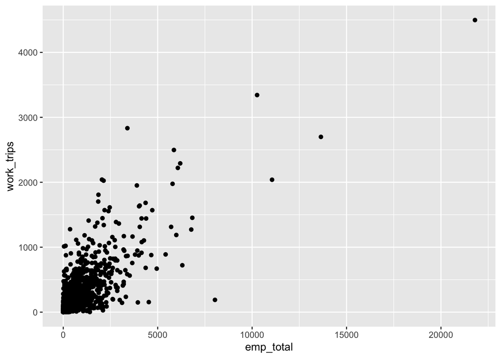

```r
work_df <- trips_df %>%
  filter(primary_purpose == "work") %>%
  group_by(destination) %>%
  summarise(work_trips = n(), .groups = "drop") %>%
  left_join(select(maz_df, mgra, emp_total), ., by = c("mgra" = "destination")) %>%
  filter(!is.na(work_trips))

ggplot(work_df, aes(x = emp_total, y = work_trips)) + geom_point()
```

```r
zero_emp_work_df <- work_df %>%
  filter(emp_total < 1) %>%
  filter(work_trips > 0)

zero_work_emp_df <- work_df %>%
  filter(emp_total > 20) %>%
  filter(work_trips < 1)
```

## Shop

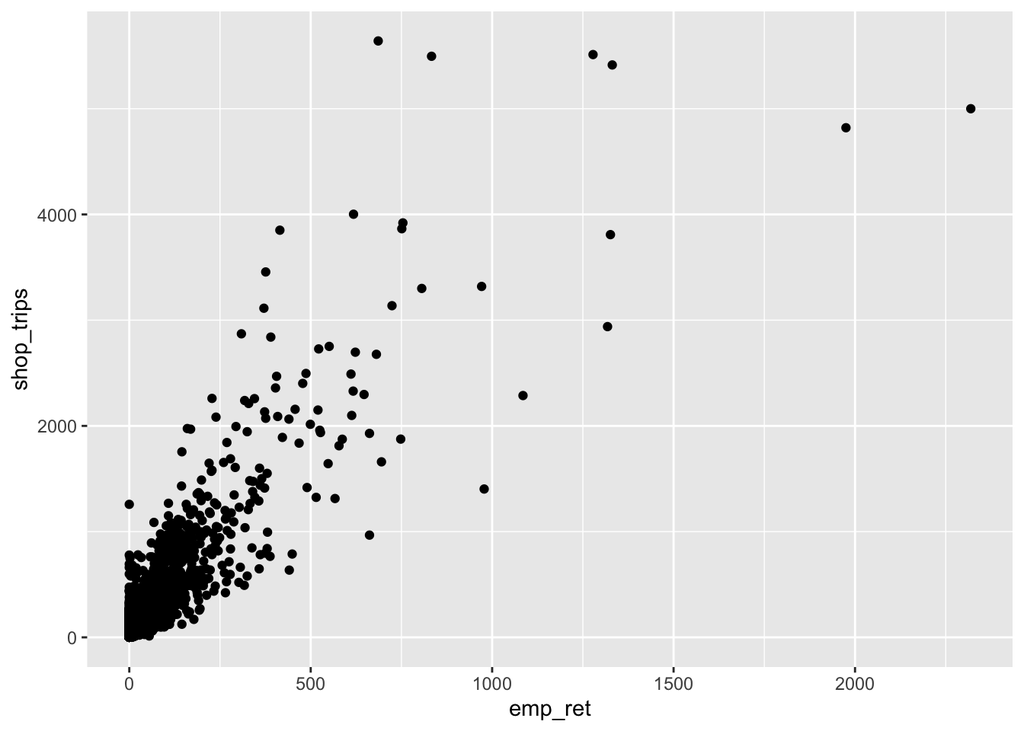

```r
shop_df <- trips_df %>%
  filter(primary_purpose == "shopping") %>%
  group_by(destination) %>%
  summarise(shop_trips = n(), .groups = "drop") %>%
  left_join(select(maz_df, mgra, emp_ret), ., by = c("mgra" = "destination")) %>%
  filter(!is.na(shop_trips))

ggplot(shop_df, aes(x = emp_ret, y = shop_trips)) + geom_point()
```

```r
zero_ret_shop_df <- shop_df %>%
  filter(emp_ret < 1) %>%
  filter(shop_trips > 0)

zero_shop_ret_df <- shop_df %>%
  filter(emp_ret > 20) %>%
  filter(shop_trips < 1)
```

# Findings

The sampling *appears* to be implemented correctly. The correlation between work trip ends and total employment is 0.802671 at the MGRA level. The number of MGRAs with zero total employment and non-zero work trips is 829 (out of 24321). The number of MGRAs with total employment of at least 20 and zero work trips is 0.

For shopping trips, the correlation between shopping trip ends and retail employment is 0.8781834 at the MGRA level. The number of MGRAs with zero retail employment and non-zero shopping trips is 17153 (out of 24321), presumably because other size terms impact shopping trips? Note to SANDAG to check the size terms for shopping trips. The number of MGRAs with retail employment of at least 20 and zero work trips is 0.

This evidence suggests the sampling is done correctly.